# Diversité de la Parcelle 6 de Paracou

Eric Marcon

07 novembre 2020

Abstract

TD du cours sur les mesures de la biodiversité

# 1 Données

## 1.1 Lecture de la base de Paracou

Inventaire de 2016. La lecture de la base de Paracou est possible sur le réseau local de Kourou à condition d’avoir les droits suffisants. Si ce n’est pas le cas, les données de la parcelle 6 en 2016 sont retournées par défaut.

```r
remotes::install_github("EcoFoG/EcoFoG", build_vignettes = TRUE)
```

```r
library("EcoFoG")
Paracou2df("Plot=6 AND CensusYear=2016") %>% # Année 2016
  # Arbres vivants seulement
  filter(CodeAlive == TRUE) %>%
  # Filtrage des colonnes utiles
  select(Plot, SubPlot:Yfield, -Project, -Protocole, Family:Species, CircCorr) %>%
  # Création d'une colonne contenant "Genre espèce".
  unite(col = spName, Genus, Species, remove = FALSE) -> Paracou
```

## 1.2 Carte

Carte des wapas de la P6.

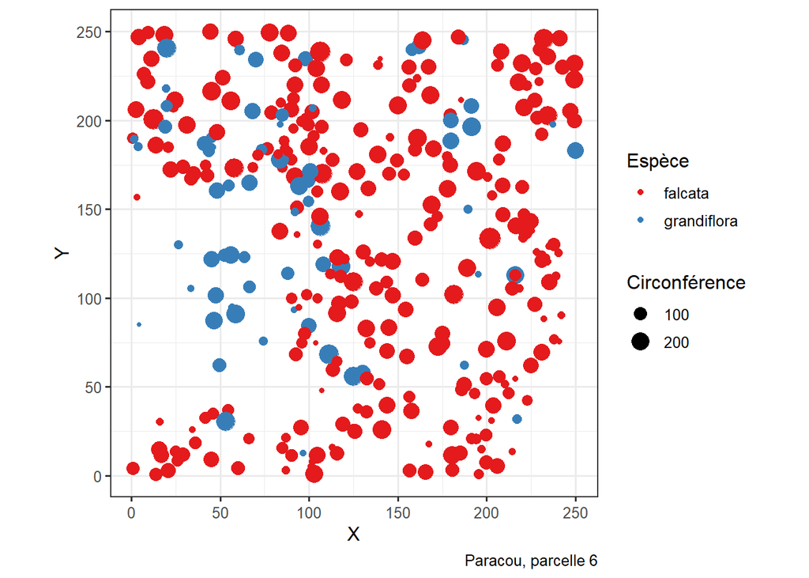

```r
Paracou %>% filter(Genus=="Eperua") %>%
  ggplot() +
  geom_point(aes(x = Xfield, y = Yfield, size = CircCorr, color=Species)) +
  coord_fixed() + scale_color_brewer(palette = "Set1") +
  labs(x="X", y="Y", caption="Paracou, parcelle 6", size="Circonférence", color="Espèce")
```

# 2 Diversité neutre

## 2.1 Préparation des données

Résumé des données à un nombre d’arbres par espèce et par parcelle

```r
# Comptage
Paracou %>%
  group_by(spName) %>%
  summarize(Abondance = length(idTree)) ->
  AbondancesP6
# Fabrication d'un vecteur nommé
AbdP6 <- AbondancesP6$Abondance
names(AbdP6) <- AbondancesP6$spName
```

## 2.2 Richesse P6

Nombre d’espèces observées

```r
library("entropart")
(AbdP6 %>% Richness(Correction="None") -> Sobserve)
```

```
## None
##  335
```

Estimation et validation

```r
(AbdP6 %>% Richness(Correction="Jackknife") -> Sestime)
```

```
## Jackknife 2
##         473
```

## 2.3 Complétude

Taux de complétude entre 50% et 74% ?

```r
Sobserve/Sestime
```

```
##      None
## 0.7082452
```

Comparaison avec Chao1

```r
AbdP6 %>% Richness(Correction="Chao1")
```

```
##    Chao1
## 417.7697
```

## 2.4 Sous-estimation

Comparaison avec Jacknife1

```r
(Singletons <- sum(AbdP6==1))
```

```
## [1] 98
```

```r
Sobserve + Singletons
```

```
## None
##  433
```

## 2.5 Intervalle de confiance

Validation de l’estimateur Jacknife 2.

Incertitude sur l’estimation : package SPECIES. Les données sont les fréquences des abondances.

```r
AbondancesP6 %>%
  group_by(Abondance) %>% summarise(Frequency=length(spName)) -> P6AbdFreqCount
library("SPECIES")
P6AbdFreqCount %>% as.matrix %>% jackknife(k=2) %$% CI
```

```
##       lb  ub
## [1,] 425 521
```

## 2.6 Taux de couverture

Estimateur de Zhang et Huang :

```r
Coverage(AbdP6)
```

```
## ZhangHuang
##  0.9723335
```

A comparer avec l’estimateur de Turing :

```r
Coverage(AbdP6, Estimator="Turing")
```

```
##    Turing
## 0.9723242
```

L’estimation rapide par le nombre de singletons (estimateur de Turing) est généralement suffisante:

```r
1-sum(AbdP6==1)/sum(AbdP6)
```

```
## [1] 0.9723242
```

## 2.7 Profil de diversité

Utilisation de l’estimateur Unveiled-Jacknife:

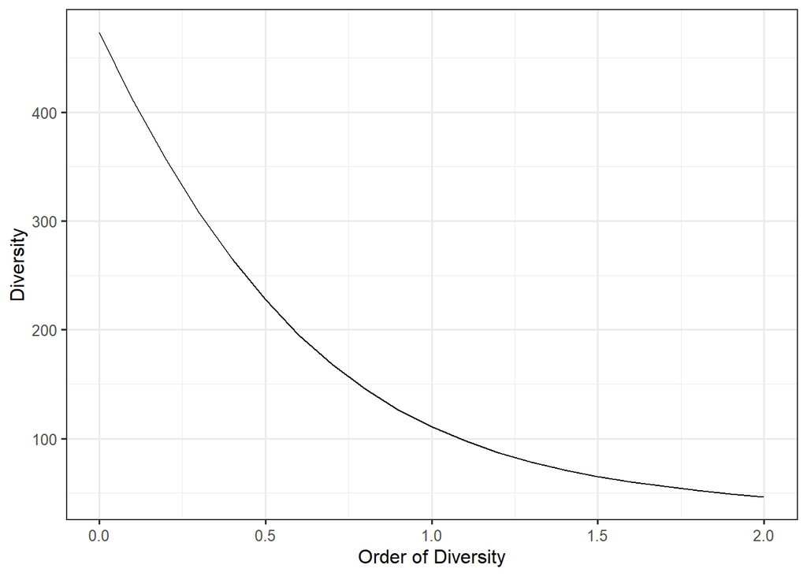

```r
CommunityProfile(Diversity, AbdP6, Correction="UnveilJ") %>%
  autoplot
```

# 3 Diversité $\beta$

## 3.1 Création d’une métacommunauté

Chaque carré de la parcelle 6 est considéré comme une communauté locale issue de la méta-communauté constituéé par la parcelle entière.

```r
Paracou %>%
  group_by(SubPlot, spName) %>%
  summarize(Abondance = length(idTree)) %>%
  spread(key = SubPlot, value = Abondance, fill=0) %>%
  as.data.frame ->
  dfP6
# Préparation d'une metacommunauté
rownames(dfP6) <- dfP6$spName
dfP6 <- dfP6[, -1]
colnames(dfP6) <- paste("C", colnames(dfP6), sep="")
library("entropart")
ParacouMC <- MetaCommunity(dfP6, Weights = colSums(dfP6))
```

## 3.2 Partition de la diversité

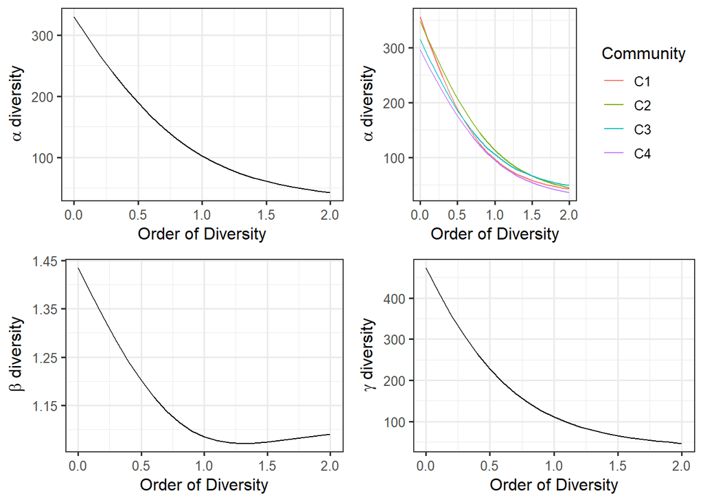

```r
dp <- DivProfile(, ParacouMC, Biased = FALSE, Correction="UnveilJ")
autoplot(dp)
```

# 4 Diversité phylogénétique

## 4.1 Création d’une phylogénie

Phylogénie à partir de la taxonomie.

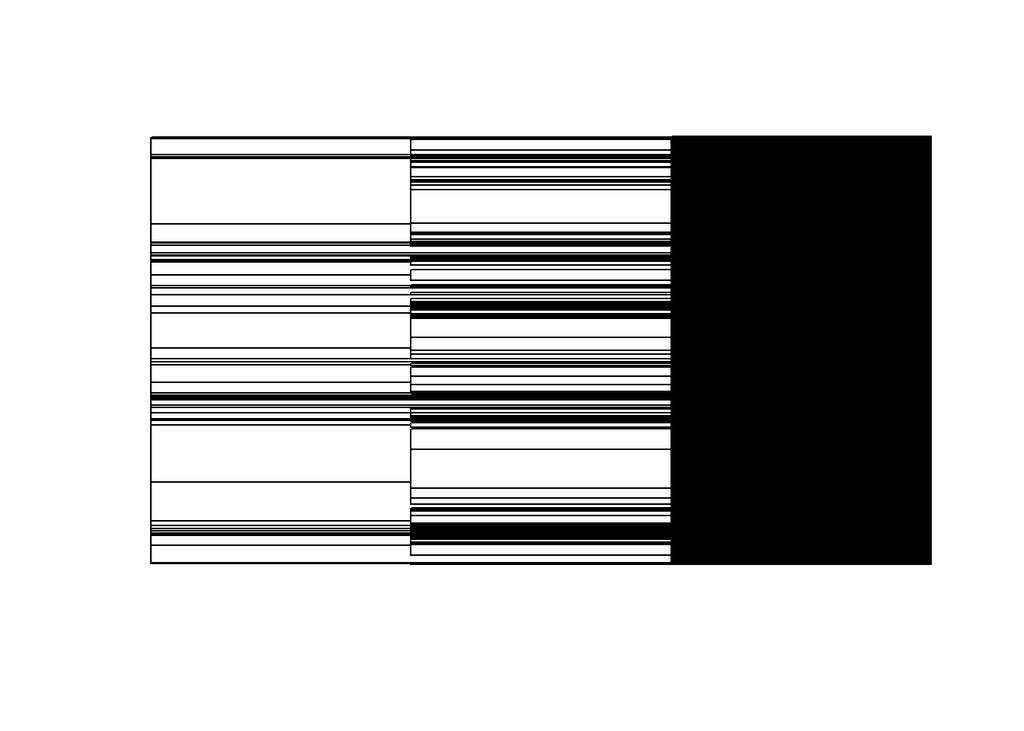

```r
library("ape")
Paracou %>%
  select(Family:Species) %>%
  unite(col=spName, Genus, Species, remove=FALSE) %>%
  mutate_if(is.character, as.factor)  %>%
  {as.phylo(~Family/Genus/spName, data=., collapse=FALSE)} %>%
  compute.brlen(method=1) %>%
  collapse.singles %>%
  multi2di %T>%
  plot(show.tip.label = FALSE) -> p6Phylo
```

## 4.2 Profil de diversité

Utilisation de l’estimateur Unveiled-Jacknife:

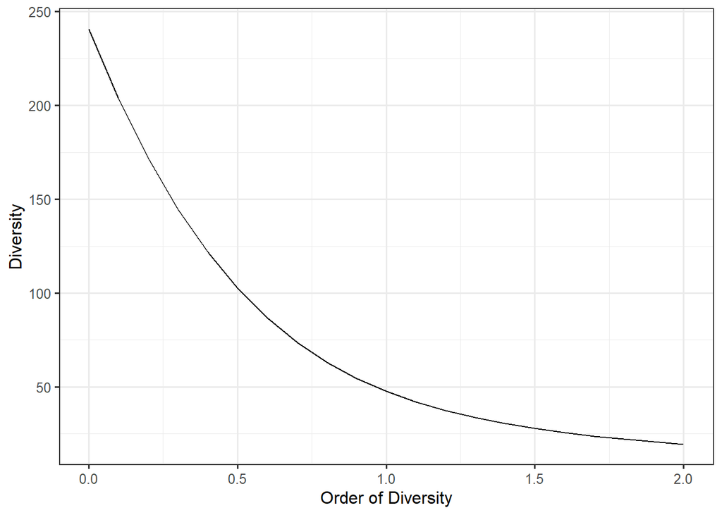

```r
dp <- CommunityProfile(function(Abd, q, CheckArguments)
  PhyloDiversity(Abd, q, Correction="UnveilJ", Tree=p6Phylo)$Total,
  AbdP6)
autoplot(dp)
```

# 5 Diversité fonctionnelle

## 5.1 Création d’une base de traits

Traits individuels (Bridge) et par espèces (Mariwenn).

```r
read_csv(file="data/ind_traits_MICE.csv") %>%
  select(Family:Species, plot_code, sapwood_dens, log_SLA) %>%
  unite(col = spName, Genus, Species, remove = FALSE) %>%
  group_by(Family, Genus, spName) %>%
  summarize(DensiteBois = median(sapwood_dens), logSLA = median(log_SLA)) %>%
  ungroup ->
  TraitsBoisFeuilles

read_csv2(file="data/DataLifeTraits.csv") %>%
  select(Name, Hauteur, Masse) %>%
  rename(spName = Name) %>%
  mutate(MasseGraine = ordered(Masse)) %>%
  select(-Masse) ->
  TraitsVie

TraitsBoisFeuilles %>%
  left_join(TraitsVie)->
  Traits
```

## 5.2 Ajout des espèces manquantes

```r
EspecesManquantes <- setdiff(AbondancesP6$spName, Traits$spName)
# Préparation des lignes supplémentaires
Paracou %>%
  filter(spName %in% EspecesManquantes) %>%
  select(Family:Genus) %>%
  distinct ->
  LignesManquantes
Traits %<>%
  bind_rows(LignesManquantes) %>%
  mutate(Family=as.factor(Family), Genus=as.factor(Genus))
```

Proportion des données de traits manquantes, pondérées par le nombre d’individus.

```r
PartTraitsManquants <- data.frame(Traitsmanquants=apply(Traits, 1, function(x) sum(is.na(x))/(length(x)-3)))
Traits %>%
  bind_cols(PartTraitsManquants) %>%
  inner_join(AbondancesP6) ->
  TraitsP6
sum(TraitsP6$Traitsmanquants * TraitsP6$Abondance)/sum(TraitsP6$Abondance)
```

```
## [1] 0.2752753
```

## 5.3 Remplissage des valeurs manquantes

```r
# Remplissage des valeurs manquantes (long calcul)
library("mice")
Traits %>%
  mice(print=FALSE) %>%
  complete ->
  Traits
```

## 5.4 Création d’une matrice de distance

Distance de Gower entre les espèces.

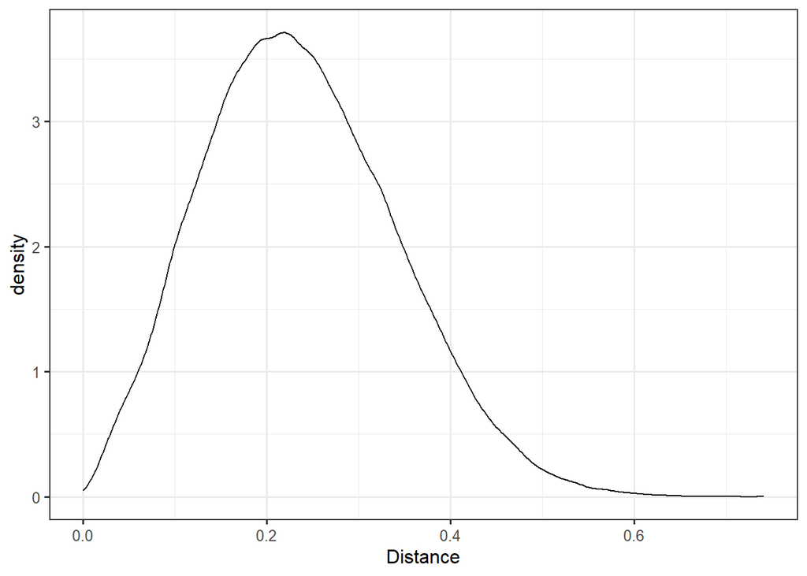

```r
library("cluster")
rownames(Traits) <- Traits$spName
Traits %>%
  select(-(Family:spName)) %>%
  daisy(metric="gower") ->
  DistEspeces

# Distribution des distances
ggplot(data=data.frame(Distance=as.numeric(DistEspeces))) +
  geom_density(aes(x=Distance))
```

```r
# Dissimilarités
DistEspeces %<>% as.matrix
Z <- 1 - DistEspeces/max(DistEspeces)
```

## 5.5 Profil de diversité

Diversité de Leinster et Cobbold.

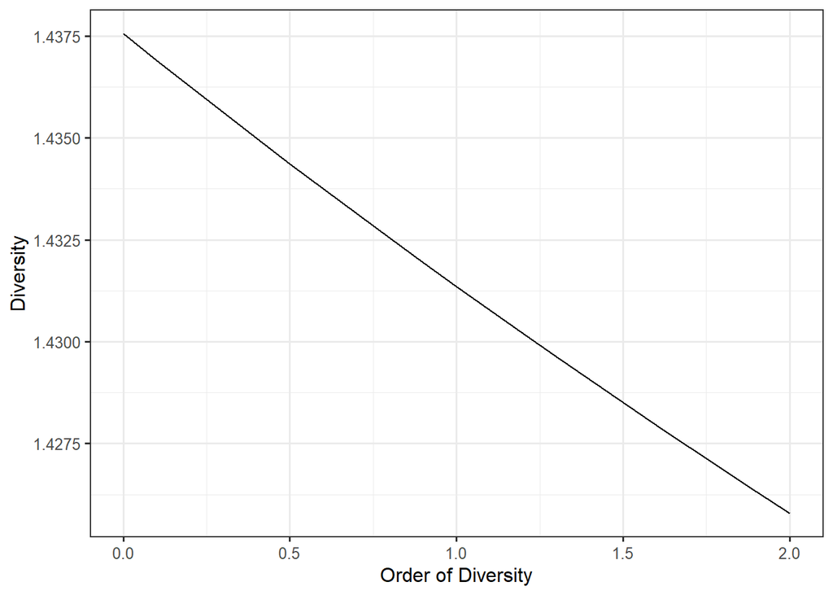

```r
# Suppression des lignes et colonnes inutiles de Z
Z <- Z[names(AbdP6), names(AbdP6)]
# Profil de diversité
CommunityProfile(Dqz, AbdP6, Z=Z) %>%
  autoplot
```